```python
import tensorflow as tf
print(tf.reduce_sum(tf.random.normal([1000, 1000])))
```

```
tf.Tensor(536.6229, shape=(), dtype=float32)
```

# Part A - 30 Marks

### DOMAIN: Electronics and Telecommunication

```python
import numpy as np
import pandas as pd
import numpy as np
import pandas as pd
import seaborn as sns
from matplotlib import pyplot as plt
import tensorflow
from sklearn.model_selection import train_test_split
from sklearn import preprocessing
from tensorflow.keras.models import Sequential
from tensorflow.keras.layers import Dense, Dropout, BatchNormalization
from sklearn.metrics import accuracy_score, confusion_matrix, precision_score, recall_score, f1_score, precision_recall_curve, auc
import matplotlib.pyplot as plt
from tensorflow.keras import optimizers
```

### 1. Data import and Understanding [10 Marks]

A. Read the ‘Signals.csv’ as DataFrame and import required libraries. [2 Marks]

```python
sig=pd.read_csv("D:\\Great Learning\\Neural Networks\\project\\signal.csv")
sig.head()
```

|  | Parameter 1 | Parameter 2 | Parameter 3 | Parameter 4 | Parameter 5 | Parameter 6 | Parameter 7 | Parameter 8 | Parameter 9 | Parameter 10 | Parameter 11 | Signal_Strength |
| --- | --- | --- | --- | --- | --- | --- | --- | --- | --- | --- | --- | --- |
| 0 | 7.4 | 0.70 | 0.00 | 1.9 | 0.076 | 11.0 | 34.0 | 0.9978 | 3.51 | 0.56 | 9.4 | 5 |
| 1 | 7.8 | 0.88 | 0.00 | 2.6 | 0.098 | 25.0 | 67.0 | 0.9968 | 3.20 | 0.68 | 9.8 | 5 |
| 2 | 7.8 | 0.76 | 0.04 | 2.3 | 0.092 | 15.0 | 54.0 | 0.9970 | 3.26 | 0.65 | 9.8 | 5 |
| 3 | 11.2 | 0.28 | 0.56 | 1.9 | 0.075 | 17.0 | 60.0 | 0.9980 | 3.16 | 0.58 | 9.8 | 6 |
| 4 | 7.4 | 0.70 | 0.00 | 1.9 | 0.076 | 11.0 | 34.0 | 0.9978 | 3.51 | 0.56 | 9.4 | 5 |

**B. Check for missing values and print percentage for each attribute. [2 Marks]**

```python
sig.isnull().sum()
```

```
Parameter 1        0
Parameter 2        0
Parameter 3        0
Parameter 4        0
Parameter 5        0
Parameter 6        0
Parameter 7        0
Parameter 8        0
Parameter 9        0
Parameter 10       0
Parameter 11       0
Signal_Strength    0
dtype: int64
```

```python
for column in sig.columns:
    print(f"Percentage for {column}:")
    print(sig[column].value_counts(normalize=True).mul(100))
print()
```

```
Percentage for Parameter 1:
7.2     4.190119
7.1     3.564728
7.8     3.314572
7.5     3.252033
7.0     3.126954
          ...
13.5    0.062539
13.8    0.062539
13.4    0.062539
4.7     0.062539
5.5     0.062539
Name: Parameter 1, Length: 96, dtype: float64
Percentage for Parameter 2:
0.600    2.939337
0.500    2.876798
0.430    2.689181
0.590    2.439024
0.360    2.376485
           ...
1.035    0.062539
0.565    0.062539
1.130    0.062539
1.115    0.062539
1.090    0.062539
Name: Parameter 2, Length: 143, dtype: float64
Percentage for Parameter 3:
0.00    8.255159
0.49    4.252658
0.24    3.189493
0.02    3.126954
0.26    2.376485
          ...
0.72    0.062539
0.62    0.062539
0.75    0.062539
1.00    0.062539
0.78    0.062539
Name: Parameter 3, Length: 80, dtype: float64
Percentage for Parameter 4:
```

[output cut: 145 more lines]

```
               ...
9.950000     0.062539
9.233333     0.062539
9.250000     0.062539
9.050000     0.062539
10.750000    0.062539
Name: Parameter 11, Length: 65, dtype: float64
Percentage for Signal_Strength:
5    42.589118
6    39.899937
7    12.445278
4     3.314572
8     1.125704
3     0.625391
Name: Signal_Strength, dtype: float64
```

**C. Check for presence of duplicate records in the dataset and impute with appropriate method. [2 Marks]**

```python
dup=sig.duplicated()
num_dup = dup.sum()
num_dup
```

```
240
```

```python
sig1=sig.drop_duplicates()

# Print the updated DataFrame
print(sig1)
```

```
      Parameter 1  Parameter 2  Parameter 3  Parameter 4  Parameter 5  \
0             7.4        0.700         0.00          1.9        0.076
1             7.8        0.880         0.00          2.6        0.098
2             7.8        0.760         0.04          2.3        0.092
3            11.2        0.280         0.56          1.9        0.075
5             7.4        0.660         0.00          1.8        0.075
...           ...          ...          ...          ...          ...
1593          6.8        0.620         0.08          1.9        0.068
1594          6.2        0.600         0.08          2.0        0.090
1595          5.9        0.550         0.10          2.2        0.062
1597          5.9        0.645         0.12          2.0        0.075
1598          6.0        0.310         0.47          3.6        0.067

      Parameter 6  Parameter 7  Parameter 8  Parameter 9  Parameter 10  \
0            11.0         34.0      0.99780         3.51          0.56
```

[output cut: 25 more lines]

**D. Visualise distribution of the target variable. [2 Marks]**

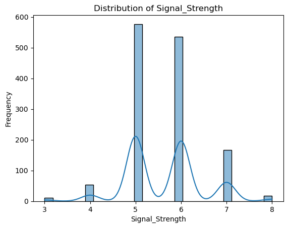

```python
sns.histplot(sig1['Signal_Strength'], kde=True)  # Set kde=True for a kernel density estimate

# Set labels and title
plt.xlabel('Signal_Strength')
plt.ylabel('Frequency')
plt.title('Distribution of Signal_Strength')

# Show the plot
plt.show()
```

**E. Share insights from the initial data analysis (at least 2). [2 Marks]**

```python
sig1.info()
```

```
<class 'pandas.core.frame.DataFrame'>
Int64Index: 1359 entries, 0 to 1598
Data columns (total 12 columns):
 #   Column           Non-Null Count  Dtype
---  ------           --------------  -----
 0   Parameter 1      1359 non-null   float64
 1   Parameter 2      1359 non-null   float64
 2   Parameter 3      1359 non-null   float64
 3   Parameter 4      1359 non-null   float64
 4   Parameter 5      1359 non-null   float64
 5   Parameter 6      1359 non-null   float64
 6   Parameter 7      1359 non-null   float64
 7   Parameter 8      1359 non-null   float64
 8   Parameter 9      1359 non-null   float64
 9   Parameter 10     1359 non-null   float64
 10  Parameter 11     1359 non-null   float64
 11  Signal_Strength  1359 non-null   int64
dtypes: float64(11), int64(1)
memory usage: 138.0 KB
```

```python
for i in sig1.describe().columns:
    print("Unique values in", i, "are :")
    print(sig1[i].value_counts())
    print("==" *25)
```

```
Unique values in Parameter 1 are :
7.2     49
7.8     48
7.1     46
7.0     44
7.5     42
        ..
13.8     1
13.4     1
4.7      1
15.0     1
5.5      1
Name: Parameter 1, Length: 96, dtype: int64
==================================================
Unique values in Parameter 2 are :
0.500    37
0.580    36
0.400    35
0.600    34
0.430    33
         ..
1.185     1
1.240     1
0.845     1
0.365     1
1.090     1
Name: Parameter 2, Length: 143, dtype: int64
==================================================
Unique values in Parameter 3 are :
0.00    118
0.49     59
0.24     41
0.02     38
0.08     32
       ...
0.72      1
0.62      1
0.71      1
0.79      1
0.78      1
```

[output cut: 157 more lines]

```
10.033333      1
13.500000      1
13.200000      1
10.750000      1
Name: Parameter 11, Length: 65, dtype: int64
==================================================
Unique values in Signal_Strength are :
5    577
6    535
7    167
4     53
8     17
3     10
Name: Signal_Strength, dtype: int64
==================================================
```

```python
sig1.describe().transpose()
```

|  | count | mean | std | min | 25% | 50% | 75% | max |
| --- | --- | --- | --- | --- | --- | --- | --- | --- |
| Parameter 1 | 1359.0 | 8.310596 | 1.736990 | 4.60000 | 7.1000 | 7.9000 | 9.20000 | 15.90000 |
| Parameter 2 | 1359.0 | 0.529478 | 0.183031 | 0.12000 | 0.3900 | 0.5200 | 0.64000 | 1.58000 |
| Parameter 3 | 1359.0 | 0.272333 | 0.195537 | 0.00000 | 0.0900 | 0.2600 | 0.43000 | 1.00000 |
| Parameter 4 | 1359.0 | 2.523400 | 1.352314 | 0.90000 | 1.9000 | 2.2000 | 2.60000 | 15.50000 |
| Parameter 5 | 1359.0 | 0.088124 | 0.049377 | 0.01200 | 0.0700 | 0.0790 | 0.09100 | 0.61100 |
| Parameter 6 | 1359.0 | 15.893304 | 10.447270 | 1.00000 | 7.0000 | 14.0000 | 21.00000 | 72.00000 |
| Parameter 7 | 1359.0 | 46.825975 | 33.408946 | 6.00000 | 22.0000 | 38.0000 | 63.00000 | 289.00000 |
| Parameter 8 | 1359.0 | 0.996709 | 0.001869 | 0.99007 | 0.9956 | 0.9967 | 0.99782 | 1.00369 |
| Parameter 9 | 1359.0 | 3.309787 | 0.155036 | 2.74000 | 3.2100 | 3.3100 | 3.40000 | 4.01000 |
| Parameter 10 | 1359.0 | 0.658705 | 0.170667 | 0.33000 | 0.5500 | 0.6200 | 0.73000 | 2.00000 |
| Parameter 11 | 1359.0 | 10.432315 | 1.082065 | 8.40000 | 9.5000 | 10.2000 | 11.10000 | 14.90000 |
| Signal_Strength | 1359.0 | 5.623252 | 0.823578 | 3.00000 | 5.0000 | 6.0000 | 6.00000 | 8.00000 |

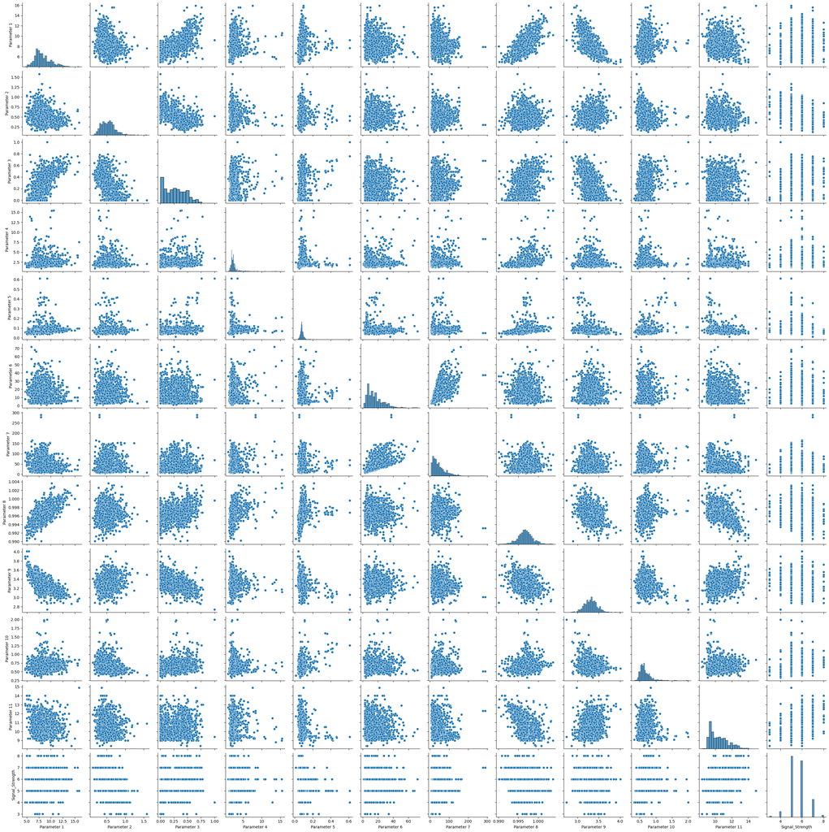

```python
sns.pairplot(sig1)
plt.show()
```

**The target variable is signal strength which has 6 classes**  
**The signal strength of most of the equipment is around 5 to 6.**  
**The highest signal strength is acheived only by 17 out of 1359 equipments tested after excluding duplicate records**

```python
sig1["Signal_Strength"].value_counts().sum
```

```
<bound method NDFrame._add_numeric_operations.<locals>.sum of 5    577
6    535
7    167
4     53
8     17
3     10
Name: Signal_Strength, dtype: int64>
```

```python
from sklearn.preprocessing import LabelEncoder

label_encoder = LabelEncoder()
sig1['Signal_Strength'] = label_encoder.fit_transform(sig1['Signal_Strength'])
sig1.head()
```

|  | Parameter 1 | Parameter 2 | Parameter 3 | Parameter 4 | Parameter 5 | Parameter 6 | Parameter 7 | Parameter 8 | Parameter 9 | Parameter 10 | Parameter 11 | Signal_Strength |
| --- | --- | --- | --- | --- | --- | --- | --- | --- | --- | --- | --- | --- |
| 0 | 7.4 | 0.70 | 0.00 | 1.9 | 0.076 | 11.0 | 34.0 | 0.9978 | 3.51 | 0.56 | 9.4 | 2 |
| 1 | 7.8 | 0.88 | 0.00 | 2.6 | 0.098 | 25.0 | 67.0 | 0.9968 | 3.20 | 0.68 | 9.8 | 2 |
| 2 | 7.8 | 0.76 | 0.04 | 2.3 | 0.092 | 15.0 | 54.0 | 0.9970 | 3.26 | 0.65 | 9.8 | 2 |
| 3 | 11.2 | 0.28 | 0.56 | 1.9 | 0.075 | 17.0 | 60.0 | 0.9980 | 3.16 | 0.58 | 9.8 | 3 |
| 5 | 7.4 | 0.66 | 0.00 | 1.8 | 0.075 | 13.0 | 40.0 | 0.9978 | 3.51 | 0.56 | 9.4 | 2 |

```python
sig1["Signal_Strength"].value_counts().sum
```

```
<bound method NDFrame._add_numeric_operations.<locals>.sum of 2    577
3    535
4    167
1     53
5     17
0     10
Name: Signal_Strength, dtype: int64>
```

### 2. Data preprocessing [7 Marks]

**A. Split the data into X & Y. [1 Marks]**

```python
X =sig1.drop(columns= ['Signal_Strength'])
Y = sig1.Signal_Strength
X
```

|  | Parameter 1 | Parameter 2 | Parameter 3 | Parameter 4 | Parameter 5 | Parameter 6 | Parameter 7 | Parameter 8 | Parameter 9 | Parameter 10 | Parameter 11 |
| --- | --- | --- | --- | --- | --- | --- | --- | --- | --- | --- | --- |
| 0 | 7.4 | 0.700 | 0.00 | 1.9 | 0.076 | 11.0 | 34.0 | 0.99780 | 3.51 | 0.56 | 9.4 |
| 1 | 7.8 | 0.880 | 0.00 | 2.6 | 0.098 | 25.0 | 67.0 | 0.99680 | 3.20 | 0.68 | 9.8 |
| 2 | 7.8 | 0.760 | 0.04 | 2.3 | 0.092 | 15.0 | 54.0 | 0.99700 | 3.26 | 0.65 | 9.8 |
| 3 | 11.2 | 0.280 | 0.56 | 1.9 | 0.075 | 17.0 | 60.0 | 0.99800 | 3.16 | 0.58 | 9.8 |
| 5 | 7.4 | 0.660 | 0.00 | 1.8 | 0.075 | 13.0 | 40.0 | 0.99780 | 3.51 | 0.56 | 9.4 |
| ... | ... | ... | ... | ... | ... | ... | ... | ... | ... | ... | ... |
| 1593 | 6.8 | 0.620 | 0.08 | 1.9 | 0.068 | 28.0 | 38.0 | 0.99651 | 3.42 | 0.82 | 9.5 |
| 1594 | 6.2 | 0.600 | 0.08 | 2.0 | 0.090 | 32.0 | 44.0 | 0.99490 | 3.45 | 0.58 | 10.5 |
| 1595 | 5.9 | 0.550 | 0.10 | 2.2 | 0.062 | 39.0 | 51.0 | 0.99512 | 3.52 | 0.76 | 11.2 |
| 1597 | 5.9 | 0.645 | 0.12 | 2.0 | 0.075 | 32.0 | 44.0 | 0.99547 | 3.57 | 0.71 | 10.2 |
| 1598 | 6.0 | 0.310 | 0.47 | 3.6 | 0.067 | 18.0 | 42.0 | 0.99549 | 3.39 | 0.66 | 11.0 |

1359 rows × 11 columns

```python
Y
```

```
0       2
1       2
2       2
3       3
5       2
       ..
1593    3
1594    2
1595    3
1597    2
1598    3
Name: Signal_Strength, Length: 1359, dtype: int64
```

**B. Split the data into train & test with 70:30 proportion.[1 Marks]**

```python
X_train, X_test, y_train, y_test = train_test_split(X,Y,test_size=0.3, random_state = 1)
```

**C. Print shape of all the 4 variables and verify if train and test data is in sync. [1 Marks]**

```python
print("Shape of Xtrain_data:", X_train.shape[0])
print("Shape of Ytrain_data:",y_train.shape[0])
print("Shape of test_data:", X_test.shape[0])
print("Shape of test_labels:", y_test.shape[0])

if X_train.shape[0] == y_train.shape[0] and  X_test.shape[0]== y_test.shape[0]:
    print("Train and test data are in sync.")
else:
    print("Train and test data are not in sync.")
```

```
Shape of Xtrain_data: 951
Shape of Ytrain_data: 951
Shape of test_data: 408
Shape of test_labels: 408
Train and test data are in sync.
```

**D. Normalise the train and test data with appropriate method. [2 Marks]**

```python
X_train = preprocessing.normalize(X_train)
y_train = np.array(y_train)
y_test = np.array(y_test)
```

```python
import collections
from collections import Counter
print("ytrain data:",Counter(y_train))
print("ytest data:",Counter(y_test))
```

```
ytrain data: Counter({2: 410, 3: 363, 4: 123, 1: 34, 5: 14, 0: 7})
ytest data: Counter({3: 172, 2: 167, 4: 44, 1: 19, 0: 3, 5: 3})
```

```python
print(Counter(Y))
```

```
Counter({2: 577, 3: 535, 4: 167, 1: 53, 5: 17, 0: 10})
```

**E. Transform Labels into format acceptable by Neural Network [2 Marks]**

```python
from tensorflow.keras.utils import to_categorical
# converting y data into categorical (one-hot encoding)
y_train = to_categorical(y_train)
y_test = to_categorical(y_test)
```

```python
print(X_train.shape, X_test.shape, y_train.shape, y_test.shape)
```

```
(951, 11) (408, 11) (951, 6) (408, 6)
```

### 3. Model Training & Evaluation using Neural Network [13 Marks]

**A. Design a Neural Network to train a classifier. [3 Marks]**

```python
from tensorflow.keras.models import Sequential
from tensorflow.keras.layers import Activation, Dense
from tensorflow.keras import optimizers
```

```python
model = Sequential()
```

```python
model.add(Dense(50, input_shape = (11, )))
model.add(Activation('sigmoid'))
model.add(Dense(50))
model.add(Activation('sigmoid'))
model.add(Dense(50))
model.add(Activation('sigmoid'))
model.add(Dense(50))
model.add(Activation('sigmoid'))
model.add(Dense(6))
model.add(Activation('softmax'))
```

```python
sgd = optimizers.SGD(learning_rate = 0.001)
model.compile(optimizer = sgd, loss = 'categorical_crossentropy', metrics = ['accuracy'])
```

**B. Train the classifier using previously designed Architecture [2 Marks]**

```python
history = model.fit(X_train, y_train, validation_split=0.2,batch_size = 200, epochs = 100, verbose = 1)
```

```python
results = model.evaluate(X_test, y_test)
```

```python
print('Test accuracy: ', results[1])
```

```
Test accuracy:  0.40931373834609985
```

**C. Plot 2 separate visuals. [3 Marks]**  
**i. Training Loss and Validation Loss**

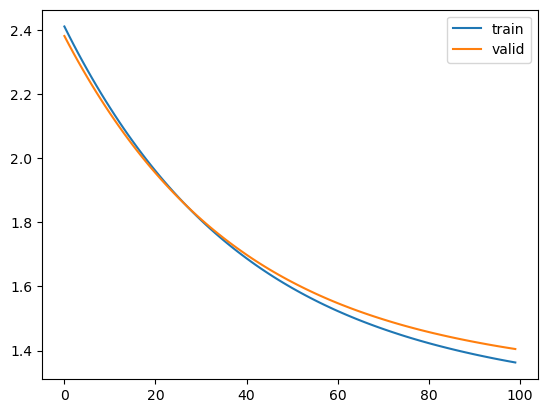

```python
hist  = pd.DataFrame(history.history)
hist['epoch'] = history.epoch

plt.plot(hist['loss'])
plt.plot(hist['val_loss'])
plt.legend(("train" , "valid") , loc =0)
```

**ii. Training Accuracy and Validation**

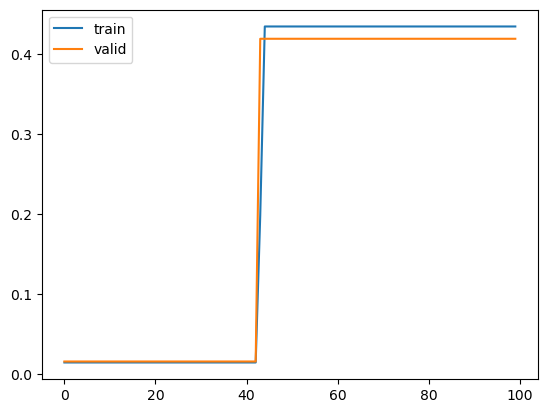

```python
plt.plot(hist['accuracy'])
plt.plot(hist['val_accuracy'])
plt.legend(("train" , "valid") , loc =0)
```

**D. Design new architecture/update existing architecture in attempt to improve the performance of the model. [2 Marks]**

### Model 2

```python
model1= Sequential()
model1.add(Dense(50, input_shape = (11, )))
model1.add(BatchNormalization())
model1.add(Activation('sigmoid'))
model1.add(Dropout(0.2))
model1.add(Dense(50))
model1.add(BatchNormalization())
model1.add(Activation('sigmoid'))
model1.add(Dropout(0.2))
model1.add(Dense(50))
model1.add(BatchNormalization())
model1.add(Activation('sigmoid'))
model1.add(Dropout(0.2))
model1.add(Dense(50))
model1.add(BatchNormalization())
model1.add(Activation('sigmoid'))
model1.add(Dropout(0.2))
model1.add(Dense(6))
model1.add(Activation('softmax'))
```

```python
#sgd1 = optimizers.SGD(learning_rate = 0.001)
optimizer = tf.keras.optimizers.Adam(0.001)
model1.compile(optimizer = optimizer, loss = 'categorical_crossentropy', metrics = ['accuracy'])
```

```python
history = model1.fit(X_train, y_train, validation_split=0.2,batch_size = 200, epochs = 100, verbose = 1)
```

```python
results = model1.evaluate(X_test, y_test)
```

```python
print('Test accuracy: ', results[1])
```

```
Test accuracy:  0.4215686321258545
```

**E. Plot visuals as in Q3.C and share insights about difference observed in both the models. [3 Marks]**

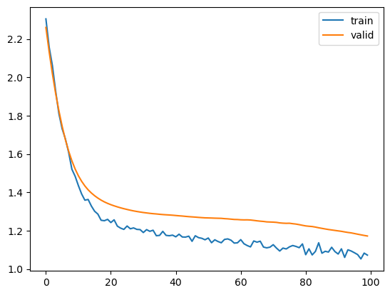

```python
hist  = pd.DataFrame(history.history)
hist['epoch'] = history.epoch

plt.plot(hist['loss'])
plt.plot(hist['val_loss'])
plt.legend(("train" , "valid") , loc =0)
```

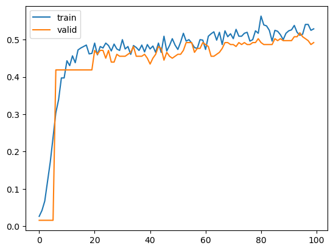

```python
plt.plot(hist['accuracy'])
plt.plot(hist['val_accuracy'])
plt.legend(("train" , "valid") , loc =0)
```

*Ideally, both the training and validation accuracies improve simultaneously compared to previous model and converge to better values.*  
*This indicates that the model is learning the underlying patterns in the data without overfitting.*  
*There is a small gap between the training and validation accuracies so good generalization is observed*

# Part B - 30 Marks

### DOMAIN: Autonomous Vehicles

### 1. Data Import and Exploration [5 Marks]**

**A. Read the .h5 file and assign to a variable. [2 Marks]**

```python
import h5py

# Open the .h5 file
file1 = h5py.File('D:\\Great Learning\\Neural Networks\\project\\SVHN.h5', 'r')
# Access the dataset within the file

file1.close()
```

**B. Print all the keys from the .h5 file. [1 Marks]**

```python
file1 = h5py.File('D:\\Great Learning\\Neural Networks\\project\\SVHN.h5', 'r')
keys = list(file1.keys())

# Print the keys
for key in keys:
    print(key)
file1.close()
```

```
X_test
X_train
X_val
y_test
y_train
y_val
```

**C. Split the data into X_train, X_test, Y_train, Y_test [2 Marks]**

```python
file1 = h5py.File('D:\\Great Learning\\Neural Networks\\project\\SVHN.h5', 'r')
dataset1 = file1['X_test']
xtest11 = np.array(dataset1)
#xtest2 = xtest11.reshape(xtest11.shape[0], -1)

## read xtrain
dtrain1 = file1['X_train']
xtrain11 = np.array(dtrain1)
#xtrain2 = xtrain11.reshape(xtrain11.shape[0], -1)
# read ytrain
ytrain1 = file1['y_train']
ytrain11 = np.array(ytrain1)
#ytrain2 = ytrain11.reshape(ytrain11.shape[0], -1)
# read ytest
ytest1 = file1['y_test']
ytest11 = np.array(ytest1)
#ytest2 = ytest11.reshape(ytest11.shape[0], -1)
# Convert the reshaped dataset to a DataFrame
#df1 = pd.DataFrame(xtest2)
#df2=pd.DataFrame(ytrain2)
#df3=pd.DataFrame(ytrain2)
#df4=pd.DataFrame(ytest2)
# Save DataFrame to a CSV file
#df1.to_csv('D:\\Great Learning\\Neural Networks\\project\\X_test.csv', index=False)
#df2.to_csv('D:\\Great Learning\\Neural Networks\\project\\X_train.csv', index=False)
#df3.to_csv('D:\\Great Learning\\Neural Networks\\project\\y_train.csv', index=False)
#df4.to_csv('D:\\Great Learning\\Neural Networks\\project\\y_test.csv', index=False)
# Close the
# Access the dataset within the file
#dval1 = file1['X_val']
#dval11 = np.array(dval1)
#dval2 = dval11.reshape(dval11.shape[0], -1)


#yval1 = file1['y_val']
#yval11 = np.array(yval1)
#yval2 = yval11.reshape(yval11.shape[0], -1)
# Convert the reshaped dataset to a DataFrame
#df11 = pd.DataFrame(dval2)
#df21=pd.DataFrame(yval2)

# Save DataFrame to a CSV file
#df11.to_csv('D:\\Great Learning\\Neural Networks\\project\\X_val.csv', index=False)
#df21.to_csv('D:\\Great Learning\\Neural Networks\\project\\y_val.csv', index=False)

# Close the file
file1.close()
```

### 2. Data Visualisation and preprocessing [13 Marks]

**A. Print shape of all the 4 data split into x, y, train, test to verify if x & y is in sync. [1 Marks]**

```python
print("The Xtrain shape is:",xtrain11.shape)
```

```
The Xtrain shape is: (42000, 32, 32)
```

```python
print("The Xtest shape is:",xtest11.shape)
```

```
The Xtest shape is: (18000, 32, 32)
```

```python
print("The ytrain shape is:",ytrain11.shape)
```

```
The ytrain shape is: (42000,)
```

```python
print("The ytest shape is:",ytest11.shape)
```

```
The ytest shape is: (18000,)
```

```python
print("The X shape using train and test size:",(xtrain11.shape[0]+xtest11.shape[0]))
```

```
The X shape using train and test size: 60000
```

```python
if xtrain11.shape[0] == ytrain11.shape[0] and  xtest11.shape[0]== ytest11.shape[0]:
    print("Train and test data are in sync.")
else:
    print("Train and test data are not in sync.")
```

```
Train and test data are in sync.
```

```python
pip install pillow
```

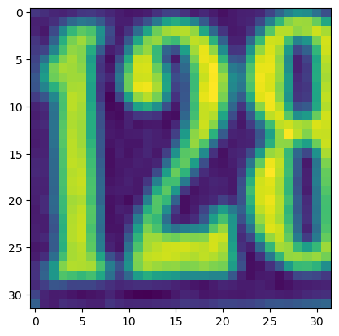

```
Label:  1
```

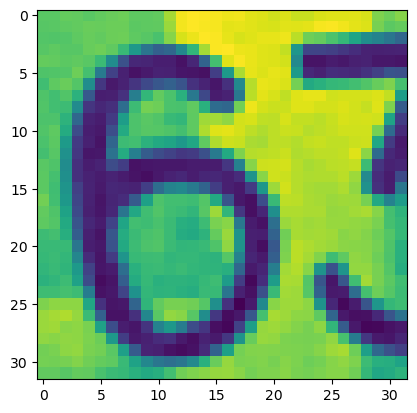

```
Label:  7
```

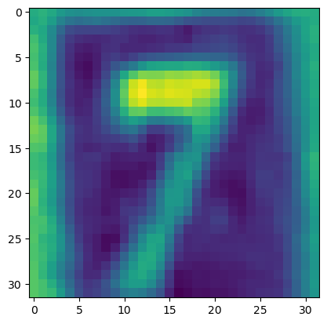

```
Label:  2
```

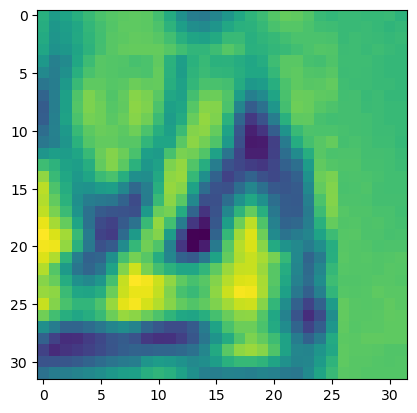

```
Label:  9
```

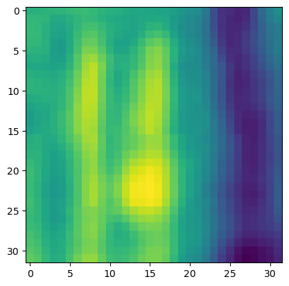

```
Label:  0
```

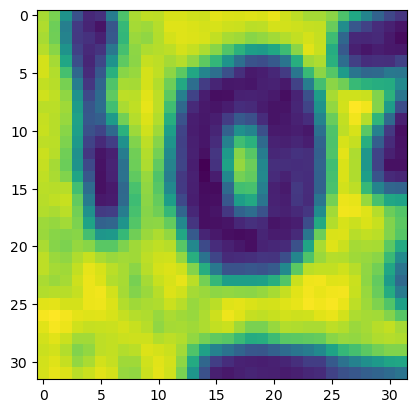

```
Label:  9
```

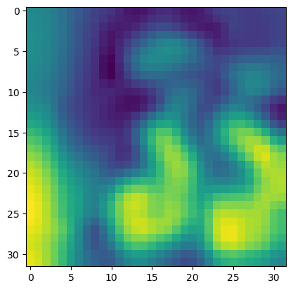

```
Label:  1
```

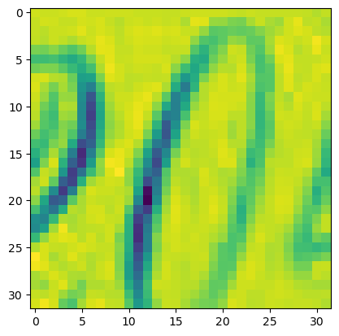

```
Label:  8
```

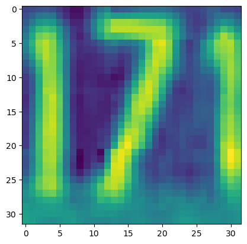

```
Label:  4
```

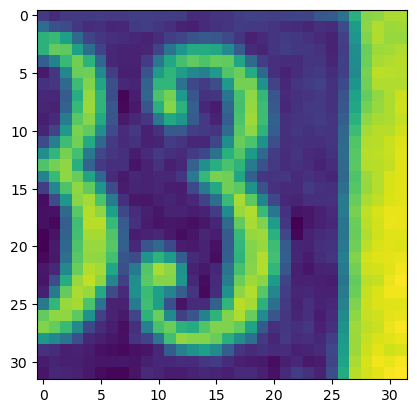

```
Label:  4
```

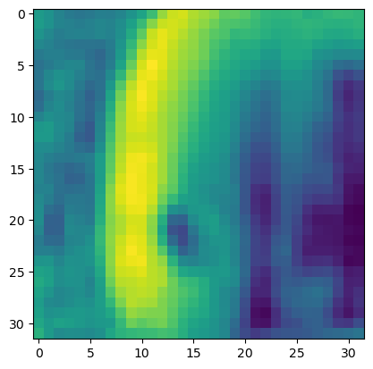

```
Label:  8
```

```python
for i in range(11):
 plt.imshow(dtrain11[i])    # show first number in the dataset
 plt.show()
 print('Label: ', ytest11[i])
```

**C. Reshape all the images with appropriate shape update the data in same variable. [3 Marks]**

```python
#X_test reshape
xtest = xtest11.reshape(xtest11.shape[0], -1)
#X_train reshape
ytrain = ytrain11.reshape(ytrain11.shape[0], -1)
#y_test reshape
ytest = ytest11.reshape(ytest11.shape[0], -1)
#y_train reshape
xtrain = xtrain11.reshape(xtrain11.shape[0], -1)
```

```python
print(xtrain.shape, xtest.shape, ytrain.shape, ytest.shape)
```

```
(42000, 1024) (18000, 1024) (42000, 1) (18000, 1)
```

**D. Normalise the images i.e. Normalise the pixel values. [2 Marks]**

```python
xtrain = preprocessing.normalize(xtrain)
ytrain = np.array(ytrain)
ytest = np.array(ytest)
```

**E. Transform Labels into format acceptable by Neural Network [2 Marks]**

```python
ytrain = to_categorical(ytrain)
ytest = to_categorical(ytest)
```

```python
print(xtrain.shape, xtest.shape, ytrain.shape, ytest.shape)
```

```
(42000, 1024) (18000, 1024) (42000, 10, 2) (18000, 10, 2)
```

**F. Print total Number of classes in the Dataset. [1 Marks]**

```python
print(ytrain.shape[1], ytest.shape[1])
```

```
10 10
```

### 3. Model Training & Evaluation using Neural Network [12 Marks]

**A. Design a Neural Network to train a classifier. [3 Marks]**

```python
from tensorflow.keras.models import Sequential
from tensorflow.keras.layers import Activation, Dense
from tensorflow.keras import optimizers
```

```python
model = Sequential()
```

```python
model.add(Dense(50, input_shape = (1024, )))
model.add(BatchNormalization())
model.add(Activation('sigmoid'))
model.add(Dense(50))
model1.add(BatchNormalization())
model.add(Activation('sigmoid'))
model.add(Dense(50))
model1.add(BatchNormalization())
model.add(Activation('sigmoid'))
model.add(Dense(50))
model1.add(BatchNormalization())
model.add(Activation('sigmoid'))
model.add(Dense(10))
model.add(Activation('softmax'))
```

```python
sgd = optimizers.SGD(learning_rate = 0.01)
model.compile(optimizer = sgd, loss = 'categorical_crossentropy', metrics = ['accuracy'])
```

```python
history = model.fit(xtrain, ytrain, validation_split=0.2,batch_size = 100, epochs = 10, verbose = 1)
```

```python
import tensorflow as tf
from tensorflow import keras

# Define the neural network architecture
model1 = keras.Sequential([
    keras.layers.Dense(128, activation='relu', input_shape=(1024,)),  # Input layer
    keras.layers.Dense(64, activation='relu'),  # Hidden layer
    keras.layers.Dense(64, activation='relu'),  # Hidden layer
    keras.layers.Dense(10, activation='softmax')  # Output layer
])
```

```python
model1.compile(optimizer='adam', loss='categorical_crossentropy', metrics=['accuracy'])
```

**B. Train the classifier using previously designed Architecture (Use best suitable parameters). [3 Marks]**

```python
hist=model1.fit(xtrain, ytrain, validation_split=0.2,epochs=100, batch_size=32)
```

**C. Evaluate performance of the model with appropriate metrics. [2 Marks]**

```python
results = model1.evaluate(xtest, ytest)
```

[output not shown]

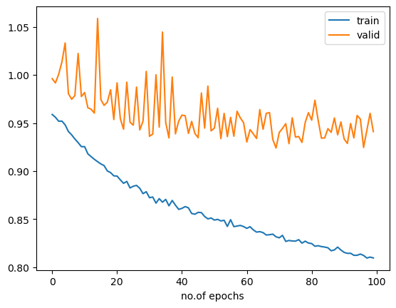

```python
hist1  = pd.DataFrame(hist.history)
hist1['epoch'] = hist.epoch

plt.plot(hist1['loss'])
plt.plot(hist1['val_loss'])
plt.xlabel("no.of epochs")
plt.legend(("train" , "valid") , loc =0)
```

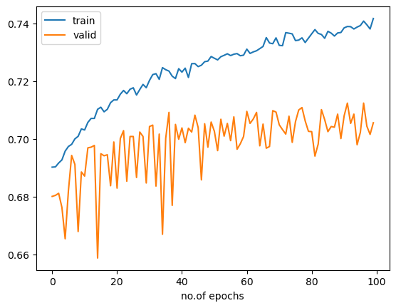

```python
plt.plot(hist1['accuracy'])
plt.plot(hist1['val_accuracy'])
plt.xlabel("no.of epochs")
plt.legend(("train" , "valid") , loc =0)
```